# Day 26 - Advanced Functions/S3

Spring 2023

[Dr. Jared Joseph](https://jnjoseph.com/)

Smith College

## Overview

### Timeline

- A Refresher on Classes and Attributes
- Making Use of the Meta
- Mechanisms of Methods

### Goal

To understand how classes and methods interact.

# A Refresher on Classes and Attributes

## Most Common Classes in R

You’re almost certainly familiar with the three most common classes in R at this point.

Almost everything in R is eventually categorized as a logical, numeric, or character vector.

These vectors can only contain one kind of information within them, and will be coerced into a more general kind if needed.

Logical Vector

````markdown
```{r}
log_vec = c(TRUE, FALSE, TRUE, TRUE, FALSE,
            FALSE, TRUE, TRUE)
class(log_vec)
```
````

```
[1] "logical"
```

Integer (Numeric) Vector

````markdown
```{r}
num_vec = 1:10
class(num_vec)
```
````

```
[1] "integer"
```

Character Vector

````markdown
```{r}
char_vec = letters[1:5]
class(char_vec)
```
````

```
[1] "character"
```

## Attributes in R

We have also bee introduced to attributes in R. Attributes at as another way to identify properties of objects.

One of the more common ways we see attributes used is for names.

Here, we can see a named vector being created in three ways, all identical.

Create a Named Vector

```r
named_vec1 = c("cat" = 5, "fish" = 1,
               "dog" = 3, "rock" = 9)
named_vec1
```

```
 cat fish  dog rock
   5    1    3    9
```

Add Names using `names()`

```r
named_vec2 = c(5, 1, 3, 9)
names(named_vec2) = c("cat", "fish",
                      "dog", "rock")
named_vec2
```

```
 cat fish  dog rock
   5    1    3    9
```

Add Names as Attribute

```r
named_vec3 = c(5, 1, 3, 9)
attr(named_vec3, "names") = c("cat", "fish",
                             "dog", "rock")
named_vec3
```

```
 cat fish  dog rock
   5    1    3    9
```

# Making Use of the Meta

## Smiple Functions Have One Job

Many functions we use in R are fairly simple.

Take `length()` as an example. No matter what you give it, it will always do the same thing: tell you how many elements are in an object.

This simplicity can become limiting with more complex function, however.

```r
length(log_vec)
```

```
[1] 8
```

```r
length(num_vec)
```

```
[1] 10
```

```r
length(char_vec)
```

```
[1] 5
```

```r
length(mtcars)
```

```
[1] 11
```

```r
length(list(log_vec, num_vec, char_vec))
```

```
[1] 3
```

## Other Functions are More Complex

Some functions change how they behave given the input.

Consider `summary()`. How does it know to change what it does based on the input?

To the right we can see some of the different ways `summary()` will behave.

```r
summary(log_vec)
```

```
   Mode   FALSE    TRUE
logical       3       5
```

```r
summary(num_vec)
```

```
   Min. 1st Qu.  Median    Mean 3rd Qu.    Max.
   1.00    3.25    5.50    5.50    7.75   10.00
```

```r
summary(char_vec)
```

```
   Length     Class      Mode
        5 character character
```

```r
summary(list(log_vec, num_vec, char_vec))
```

```
     Length Class  Mode
[1,]  8     -none- logical
[2,] 10     -none- numeric
[3,]  5     -none- character
```

## Getting Function to React

One way to accomplish this reactivity is with conditions such as `if() else` code.

We can imagine summary working like the code on the right.

However, that would not be quite correct. Instead it just says `UseMethod("summary")`.

It could be…

```r
if(object is logical){

  Do logical stuff

} else if(object is numeric){

  Do numeric stuff

} else if(object is character){

  Do character stuff

}
```

However, it really is …

```r
summary
```

```
function (object, ...)
UseMethod("summary")
<bytecode: 0x0000019e9f596358>
<environment: namespace:base>
```

What is that?

## The Many Faces of `Summary()`

If we *did* need to write an `if()` for everything `summary()` did, the function would be massive!

It would also mean that every time someone wanted to create a new summary for their package or custom object, they would need to edit or overwrite the base `summary()`.

Given we routinely have many packages loaded at once, that isn’t really sustainable.

```r
summary(mtcars[, 1:3])
```

```
      mpg             cyl             disp
 Min.   :10.40   Min.   :4.000   Min.   : 71.1
 1st Qu.:15.43   1st Qu.:4.000   1st Qu.:120.8
 Median :19.20   Median :6.000   Median :196.3
 Mean   :20.09   Mean   :6.188   Mean   :230.7
 3rd Qu.:22.80   3rd Qu.:8.000   3rd Qu.:326.0
 Max.   :33.90   Max.   :8.000   Max.   :472.0
```

```r
summary(lm(mpg ~ disp + wt, data = mtcars))
```

```
Call:
lm(formula = mpg ~ disp + wt, data = mtcars)

Residuals:
    Min      1Q  Median      3Q     Max
-3.4087 -2.3243 -0.7683  1.7721  6.3484

Coefficients:
            Estimate Std. Error t value Pr(>|t|)
(Intercept) 34.96055    2.16454  16.151 4.91e-16 ***
disp        -0.01773    0.00919  -1.929  0.06362 .
wt          -3.35082    1.16413  -2.878  0.00743 **
---
Signif. codes:  0 '***' 0.001 '**' 0.01 '*' 0.05 '.' 0.1 ' ' 1

Residual standard error: 2.917 on 29 degrees of freedom
Multiple R-squared:  0.7809,    Adjusted R-squared:  0.7658
F-statistic: 51.69 on 2 and 29 DF,  p-value: 2.744e-10
```

## Introducing Methods

Rather than editing one big function, we can instead create a *method* for each class of object we want our function to work with.

This lets a single *generic function* coordinate a common task with several different *methods* of accomplishing that task in different contexts.

For example, `sumamry()` is really a generic function calling all of the *methods* we see here!

```r
methods(summary)
```

```
 [1] summary.aov                         summary.aovlist*
 [3] summary.aspell*                     summary.check_packages_in_dir*
 [5] summary.connection                  summary.data.frame
 [7] summary.Date                        summary.default
 [9] summary.ecdf*                       summary.factor
[11] summary.glm                         summary.infl*
[13] summary.lm                          summary.loess*
[15] summary.manova                      summary.matrix
[17] summary.mlm*                        summary.nls*
[19] summary.packageStatus*              summary.POSIXct
[21] summary.POSIXlt                     summary.ppr*
[23] summary.prcomp*                     summary.princomp*
[25] summary.proc_time                   summary.rlang:::list_of_conditions*
[27] summary.rlang_error*                summary.rlang_message*
[29] summary.rlang_trace*                summary.rlang_warning*
[31] summary.srcfile                     summary.srcref
[33] summary.stepfun                     summary.stl*
[35] summary.table                       summary.tukeysmooth*
[37] summary.warnings
see '?methods' for accessing help and source code
```

# Mechanisms of Methods

## Creating a New Method

The most simple way to create methods in R is the S3 style, named for the S language R grew from.

The syntax goes:

generic_function.class_name =  
function(x){  
When generic_function is called  
on an object of class  
class_name, do this to x.  
}

Keep in mind this only works for generic functions!

Make object of class `SuperCool`

```r
test_vec = 1:5
class(test_vec) = "SuperCool"
```

Define a method to the generic `summary()` function for class `SuperCool`

```r
summary.SuperCool = function(x){
  cat("There are", length(x),
      "cool things in this vector.\n")
  cat("What more do you need to know?")
}
```

Then run `summary()`

```r
summary(test_vec)
```

```
There are 5 cool things in this vector.
What more do you need to know?
```

## Using Multiple Methods

Say we still wanted to get the normal information we would get for numeric vectors like `test_vec`.

We can do that by letting our `SuperCool` method pass the object to another method.

In this way, we can re-use some code if objects have multiple classes.

Modify our `SuperCool` summary method to use the next method, in this case the summary for the `numeric` class

```r
summary.SuperCool = function(x){
  cat("There are", length(x),
      "cool things in this vector.\n")

  NextMethod()
}
```

Rerun our `SuperCool` summary

```r
summary(test_vec)
```

```
There are 5 cool things in this vector.
```

```
   Min. 1st Qu.  Median    Mean 3rd Qu.    Max.
      1       2       3       3       4       5
```

## A Visual

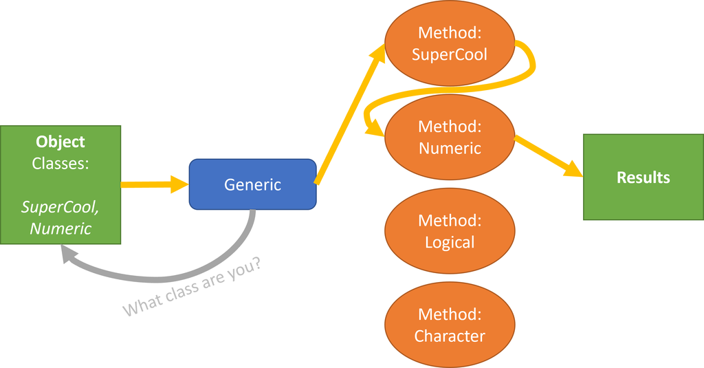

# Code-Along

## For Next Time

### Topic

Finals Work Time 1

### To-Do

- Finish Worksheet

SDS 270: Advanced Programming for Data Science